# Tutorial: Cluster redshift distribution (on a grid)

From the 1-parameter model you fit in the Bayes' Law notebook, we are moving on to... a 2-parameter model! This will be the relatively comfortable and tractable problem where you try out a few different methods: grid-based methods in this notebook, and more scalable methods in the next.

This is likely also the last time in the course that you will be evaluating posterior distributions on a grid, since in general this is horribly inefficient. Indeed, getting an appreciation for that fact is part of the reason we're going through it here. We will also use this tutorial as an opportunity to work through the process of finding maximum-likelihood estimates and confidence regions, since their calculation on a grid is mechanically quite similar to the Bayesian results.

Specifically, you will

- define a generative model for redshifts of the member galaxies of a cluster
- apply Bayes' Law, evaluating the posterior over a grid in parameter space
- compute credible intervals and regions
- qualitatively evaluate the goodness of fit
- compute analogous results using the maximum-likelihood approach

```python
# !pip install incredible

from yaml import safe_load
import numpy as np
import scipy.stats as st
import matplotlib.pyplot as plt
%matplotlib inline

import incredible as cr
```

```python
thisTutorial = 'on_a_grid'

## Set the variable `datapath` to the path to the data for this tutorial.

## If you are working in Colab, it will be something like:
#from google.colab import drive
#drive.mount('/content/drive')
#datapath = '/content/drive/MyDrive/Physics267_data/' + thisTutorial + '/'

## Otherwise, it can be an absolute path or relative to the current directory, as in
#datapath = '../../data/' + thisTutorial + '/'

# YOUR CODE HERE
raise NotImplementedError()
```

```python
# do not mess with the housekeeping
# Tests housekeeping
```

## Background

Since the emphasis here is on methodology, we'll use a relatively simple data set and model. The data are spectroscopically determined redshifts for galaxies in cluster XLSSC 122 ([Willis et al. 2020](https://ui.adsabs.harvard.edu/abs/2020Natur.577...39W)). The cluster was discovered earlier through its X-ray emission, and intially assigned a photometrically determined redshift of $1.9 \pm 0.2$. This is (still, at this writing) an extremely high redshift for a massive cluster, and as a result pinning it down more precisely (i.e. spectroscopically) required space-based data, hence the Hubble observations presented by Willis et al. (In fact, this is a rare case where the first spectroscopic redshift came from follow-up X-ray data... which is not relevant, since the Hubble redshift is 100 times more precise, but still fun.)

Here is the top of the data table from the paper, showing redshifts measured for individual galaxies. We'll be using these galaxy redshifts to estimate the redshift of the cluster itself, assuming they follow a known distribution.

| ID | RA | Dec | Magnitude | Colour | Redshift | Notes |
| --- | --- | --- | --- | --- | --- | --- |
| 526 | 34.43422 | -3.75880 | 20.64 | 1.44 | 1.980 | G |
| 451 | 34.42228 | -3.76351 | 21.95 | 1.29 | 1.981 | G |
| 657 | 34.43410 | -3.75766 | 21.67 | 1.49 | 1.983 | G |
| 1032 | 34.43245 | -3.74992 | 22.38 | 1.33 | 1.982 | G |
| 295 | 34.43503 | -3.76795 | 22.50 | 1.56 | 1.987 | G |
| ... | ... | ... | ... | ... | ... | ... |

The data in the public data directory are the "G" and "GE" class redshifts from this table, which is a bit sketchy, as a redshift cut is already used in those classifications. We're keeping it simple in this notebook, and just using the data to demonstrate some of our methods.

In any case, as usual, the data you'll be using have been randomly generated just for you! Let's read them in:

```python
z_gal = np.loadtxt(datapath+'redshifts.txt')
z_gal
```

```
array([1.98 , 1.981, 1.983, 1.982, 1.987, 1.963, 1.993, 1.977, 1.988,
       1.966, 1.977, 1.979, 1.963, 1.996, 1.976, 1.991, 1.981, 1.962,
       1.979, 1.963, 1.972, 1.993, 1.997, 1.969, 1.971, 1.981, 1.977,
       1.963, 1.977, 1.979, 1.978, 1.972, 1.976])
```

This will show a histogram of the galaxy redshifts:

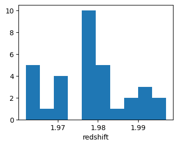

```python
plt.rcParams['figure.figsize'] = (4.0, 3.0)
plt.hist(z_gal);
plt.xlabel('redshift');
```

## Define the model and priors

Physically, we expect the distribution of cluster member velocities (hence redshifts) to be approximately Gaussian. Our model will therefore simply be that the redshifts above follow a Gaussian distribution, whose mean is the cluster redshift. The width of the distrbution is related to the mass of the cluster, although we won't pursue that here other than obtaining constraints on the width itself.

Let's parameterize the model with

- the Gaussian's mean, $\mu$, and
- its standard deviation, $\sigma$.

We will call these `mu` and `sigma` in code, and conventionally order them that way. It's also nice to have properly formatted axis labels in our plots, for which we can use the following:

```python
param_labels = [r'$\mu$', r'$\sigma$']
```

Next, you will need to choose priors for parameters. This is something we will discuss in class, and for grading purposes you should turn in a notebook that uses the priors that we jointly decide on.

With that presumably done, draw the PGM and specify all the probabilistic relationships in the model.

> Space for PGM and generative model

It's always a good idea to make plots of your priors to verify that they are, in fact, as reasonable and defensible as you hoped. We'll do this below, after implementing them in code.

Finally, because it's good practice, define a dictionary to hold the values of the prior hyperparameters here.

```python
# hyperparameters = {...}

# YOUR CODE HERE
raise NotImplementedError()
```

## Implement and benchmark the model functions

It's time to write functions to evaluate the prior, sampling and posterior distributions. We'll be evaluating them all over a grid, so they should be able to take array-valued parameter arguments, and return arrays of the same shape.

Normally, we try to evaluate the *log* of these distributions. This is because floating-point underflows can be an issue, especially when the sampling distribution is a product with many terms. (That's unlikely to be an issue in this problem, but happens naturally when the data consist of many measurements.) Another benefit is that we don't have to worry about normalizing coefficients that don't depend on model parameters, unless we wanted to compute the absolute value of the evidence for some reason. Since we'll be evaluating over a grid in this notebook, we could always normalize the posterior later by dividing it by its numerical integral.

If any of these functions should return zero probability, you can and should have them return a log-probability of $-\infty$. This includes cases where parameters are somehow out of bounds or would cause less elegant numerical errors, e.g. $\sigma<0$ for the first condition, but potentially also $\sigma=0$ for the second. Our solution will be on a grid, so it would be easy to simply not include any pathological values in the range to be explored. However, we will soon move to using algorithms that might ask for an evaluation at any real value, in principle, so it's a good habit to watch out for cases that might crash your code and handle them proactively. `scipy.stats` functions usually deal with this kind of checking automatically, which can simplify things.

### Prior

Complete the following function for evaluating the log-prior, which should work for any choice of the hyperparameters' values.

```python
# def log_prior(mu, sigma, YOUR, HYPERPARAMETERS, HERE):
      # return the log-prior density
      # mu, sigma: scalars or arrays of the same shape
      # hyperparameters: scalars
      # return value: scalar or array with the same shape as mu and sigma

# YOUR CODE HERE
raise NotImplementedError()
```

Let's have a look at this prior. We'll need to define a region of parameter space over which to plot it, which is a bit hard for us to do in advance, not knowing what prior will be chosen! So below, define linearly spaced grids of $\mu$ and $\sigma$ that span the prior. If one or both is improper, have the grid span a wide range that you're *really* confident will contain nearly all of the posterior probability. We strongly suggest making the grids different lengths; this will help avoid indexing mix-ups later.

```python
# grid_mu = np.linspace(...)
# grid_sigma = np.linspace(...)

# YOUR CODE HERE
raise NotImplementedError()
```

We'll be evaluating the prior, and eventually the likelihood and posterior, over a 2D grid defined by each of these. It's convenient, if not actually efficient, to carry around additional 2D grids that tell us, for each element, what the values of $(\mu,\sigma)$ are. That way, we can use `numpy`'s array arithmetic to compactly code operations over the entire 2D grid. The following utility function helps with this:

```python
grid2_mu, grid2_sigma = np.meshgrid(grid_mu, grid_sigma)
```

If the description above was unclear, hopefully plotting these two arrays explains why they're helpful.

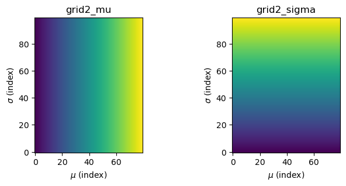

```python
plt.rcParams['figure.figsize'] = (8.0, 3.0)
fig, ax = plt.subplots(1,2);
ax[0].imshow(grid2_mu, origin='lower')
ax[0].set_title("grid2_mu");
ax[0].set_xlabel(param_labels[0]+' (index)');
ax[0].set_ylabel(param_labels[1]+' (index)');
ax[1].imshow(grid2_sigma, origin='lower')
ax[1].set_title("grid2_sigma");
ax[1].set_xlabel(param_labels[0]+' (index)');
ax[1].set_ylabel(param_labels[1]+' (index)');
```

Finally, note that our conventional parameter order $(\mu,\sigma)$ is *not* the indexing order for these 2D arrays, or anything we make from them. You can see this in the 2D grid dimensions, if you followed our advise to make the 1D grids different lengths:

```python
grid2_mu.shape
```

```
(100, 80)
```

This annoyance is due to the conflicting convention for indexing tables in (row,column) order, versus the physics and math convention of ordering $x$ (horizontal position) before $y$ (vertical position). Another reason to let `meshgrid` give us arrays of $\mu$ and $\sigma$ values instead of dealing with indexing ourselves.

All that aside, we should now be able to pass `grid2_mu` and `grid2_sigma` to your `log_prior` function, evaluating it over this grid in parameter space in one line. The cell below will do this, and then display the result using color scaling (left) and a series of contours (right). Whatever information we decided to encode in the prior should be qualitatively discernable in these plots.

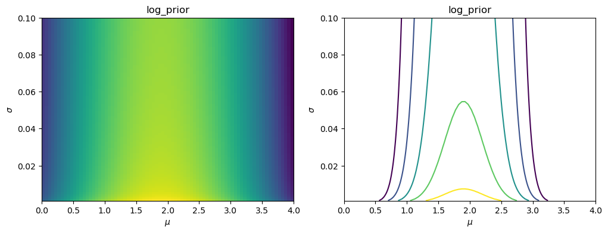

```python
# Checkpoint prior2d_byI 0
grid2_lnprior = log_prior(grid2_mu, grid2_sigma, **hyperparameters)

plt.rcParams['figure.figsize'] = (12.0, 4.0)
fig, ax = plt.subplots(1,2);
ax[0].imshow(grid2_lnprior, origin='lower', extent=[grid_mu[0], grid_mu[-1], grid_sigma[0], grid_sigma[-1]], aspect='auto');
ax[0].set_title("log_prior");
ax[0].set_xlabel(param_labels[0]);
ax[0].set_ylabel(param_labels[1]);
ax[1].contour(grid2_mu, grid2_sigma, grid2_lnprior, levels=grid2_lnprior.max()-np.arange(10.0, 0.0, -2.0));
ax[1].set_title("log_prior");
ax[1].set_xlabel(param_labels[0]);
ax[1].set_ylabel(param_labels[1]);
# End checkpoint
```

For completeness, it would be nice to verify the 1D marginal prior distributions of each parameter are what we intended. Marginalize over `grid2_lnprior` appropriately (remember Essential Probability?) and we'll plot these below.

```python
# marg_mu_prior = ...
# marg_sigma_prior = ...

# YOUR CODE HERE
raise NotImplementedError()
```

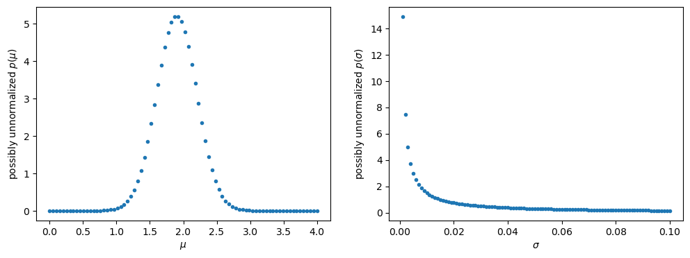

```python
# Checkpoint prior1d_byI 0
plt.rcParams['figure.figsize'] = (12.0, 4.0)
fig, ax = plt.subplots(1,2);
ax[0].plot(grid_mu, marg_mu_prior, '.');
ax[0].set_xlabel(param_labels[0]);
ax[0].set_ylabel('possibly unnormalized $p($'+param_labels[0]+'$)$');
ax[1].plot(grid_sigma, marg_sigma_prior, '.');
ax[1].set_xlabel(param_labels[1]);
ax[1].set_ylabel('possibly unnormalized $p($'+param_labels[1]+'$)$');
# End checkpoint
```

If the grids are not wide enough and/or well sampled enough to (1) show the prior going to ~zero where it should and (2) show the shape of each PDF, then adjust their definitions and repeat this part.

```python
# this will test the log-prior function against our solution
# Tests logprior (1 point)
```

```python
# this will test the marginalized grids
# Tests margeprior (1 point)
```

### Sampling distribution (aka likelihood)

Next implement the likelihood function for this analysis.

```python
# def log_likelihood(data, mu, sigma):
    # return the log-likelihood
    # data: 1D array of measured redshifts
    # mu, sigma: scalars or arrays of the same shape
    # return value: scalar or array with the same shape as mu and sigma

# YOUR CODE HERE
raise NotImplementedError()
```

We will evaluate this over the 2D parameter grid and visualize it in the same way as we did for the prior:

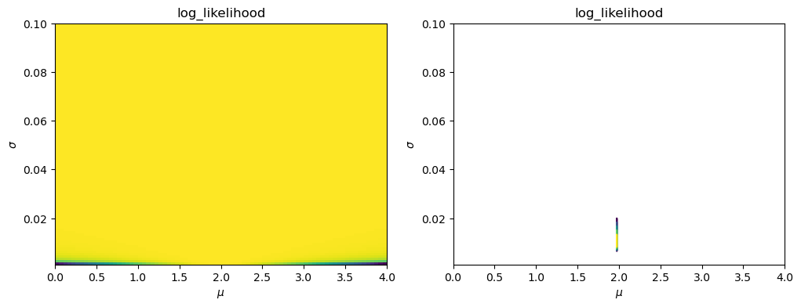

```python
grid2_lnlike = log_likelihood(z_gal, grid2_mu, grid2_sigma)

plt.rcParams['figure.figsize'] = (12.0, 4.0)
fig, ax = plt.subplots(1,2);
ax[0].imshow(grid2_lnlike, origin='lower', extent=[grid_mu[0], grid_mu[-1], grid_sigma[0], grid_sigma[-1]], aspect='auto');
ax[0].set_title("log_likelihood");
ax[0].set_xlabel(param_labels[0]);
ax[0].set_ylabel(param_labels[1]);
ax[1].contour(grid2_mu, grid2_sigma, grid2_lnlike, levels=grid2_lnlike.max()-np.arange(10.0, 0.0, -2.0));
ax[1].set_title("log_likelihood");
ax[1].set_xlabel(param_labels[0]);
ax[1].set_ylabel(param_labels[1]);
```

This may or may not be very enlightening. For example, in our solutions the grid size is much bigger than the region where the likelihood is large, resulting in tiny contours in the right-hand figure, while the bottom corners of the left plot contain such negative values that the rest is uniformly colored. You can play with the grid extent to make this more informative, although we will refine it below in any case.

```python
# this will test the log-likelihood function against our solution
# Tests loglike (1 point)
```

### Posterior distribution and benchmarking

Finally, the log-posterior. As will often be the case, we will just return the sum of the log-prior and log-likelihood, i.e. we will neglect the normalizing constant (evidence), which is constant with repect to the model parameters. We will not insult you by asking you to implement this.

```python
def log_posterior(mu, sigma, data, **hyperpar):
    return log_prior(mu, sigma, **hyperpar) + log_likelihood(data, mu, sigma)
```

You've already evaluated the relevent functions many times, but in general we would want to have an idea of how long our posterior takes to evaluate before launching into an analysis. To that end, use the following cell to benchmark `log_posterior`. You can reduce the number of iterations if 1000 takes a long time to complete (though it might be a good idea to look at your code if it does).

```python
%%time
for i in range(1000):
    log_posterior(grid2_mu, grid2_sigma, z_gal, **hyperparameters);
```

```
CPU times: user 449 ms, sys: 902 μs, total: 450 ms
Wall time: 450 ms
```

As an exercise, let's use this to estimate how long it would take to execute over a grid with 100 points in each dimension as the number of model parameters increases. In practice, 100 points is not a particularly big number if we want to constrain the shape of the posterior distribution with any accuracy.

According to the solutions, my posterior function executes over the grid in about 0.5 ms (on a 2025 laptop). You can take that as a benchmark, or replace the number 5e-4 in the cells below to whatever you found.

```python
t1 = 5e-4/np.prod(grid2_mu.shape)
for i in range(2, 9):
    t = t1 * 100**i
    print('For', i, 'parameters times 100 grid points:', t, 'sec (', np.round(t/60,1), 'min /', np.round(t/3600,1), 'hr /', np.round(t/3600/24,1), 'dy)')
```

```
For 2 parameters times 100 grid points: 0.000625 sec ( 0.0 min / 0.0 hr / 0.0 dy)
For 3 parameters times 100 grid points: 0.0625 sec ( 0.0 min / 0.0 hr / 0.0 dy)
For 4 parameters times 100 grid points: 6.25 sec ( 0.1 min / 0.0 hr / 0.0 dy)
For 5 parameters times 100 grid points: 625.0 sec ( 10.4 min / 0.2 hr / 0.0 dy)
For 6 parameters times 100 grid points: 62500.0 sec ( 1041.7 min / 17.4 hr / 0.7 dy)
For 7 parameters times 100 grid points: 6250000.0 sec ( 104166.7 min / 1736.1 hr / 72.3 dy)
For 8 parameters times 100 grid points: 625000000.0 sec ( 10416666.7 min / 173611.1 hr / 7233.8 dy)
```

Even for this relatively fast problem with a relatively course grid, you can see how things get inconvenient fairly quickly as a function of the number of parameters.

In real life, we might run a course grid to identify the region of parameter space where the posterior is large (we might even need to iterate this a few times), and then finish with a finer grid to resolve the details of the posterior. Here's how the above calculation scales for grids with 1000 points along each dimension:

```python
t1 = 5e-4/np.prod(grid2_mu.shape)
for i in range(2, 6):
    t = t1 * 1000**i
    print('For', i, 'parameters times 1000 grid points:', t, 'sec (', np.round(t/60,1), 'min /', np.round(t/3600,1), 'hr /', np.round(t/3600/24,1), 'dy)')
```

```
For 2 parameters times 1000 grid points: 0.0625 sec ( 0.0 min / 0.0 hr / 0.0 dy)
For 3 parameters times 1000 grid points: 62.5 sec ( 1.0 min / 0.0 hr / 0.0 dy)
For 4 parameters times 1000 grid points: 62500.0 sec ( 1041.7 min / 17.4 hr / 0.7 dy)
For 5 parameters times 1000 grid points: 62500000.0 sec ( 1041666.7 min / 17361.1 hr / 723.4 dy)
```

All of this is to say: grid-based calculations are a perfectly respectable approach for models with just a few parameters, depending on how fast your likelihood function is and how much time you're willing to spend manually running and adjusting grid spacings. Fortunately, there are less brute-force approaches, and we'll cover them shortly. In practice, I normally recommend working on the grid only for 1- or 2-parameter models.

## Bayesian results

Analogously to the section on the prior distribution, here we will want our grid to be large enough in extent that we can see the posterior going to zero (or running into a boundary, e.g. $\sigma=0$) and finely spaced enough that the shape of the posterior is clear. What the means will be spelled out below, but we provide the cell below so that you can redefine the grid and iterate this section as needed.

```python
# grid_mu = np.linspace(...)
# grid_sigma = np.linspace(...)
# grid2_mu, grid2_sigma = np.meshgrid(grid_mu, grid_sigma)

# YOUR CODE HERE
raise NotImplementedError()
```

All being well, we should be able to straightforwardly evaluate the log-posterior over the grid.

```python
grid2_lnpost = log_posterior(grid2_mu, grid2_sigma, z_gal, **hyperparameters)
```

We'll visualize the results as before.

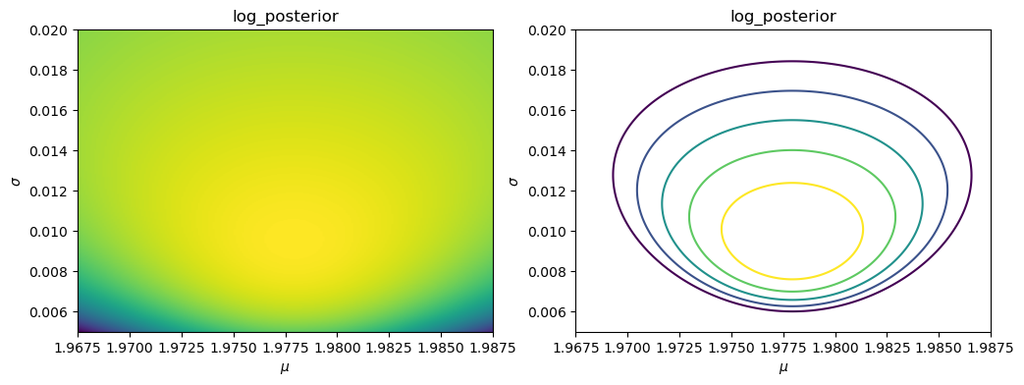

```python
# Checkpoint post2d_byI 0
plt.rcParams['figure.figsize'] = (12.0, 4.0)
fig, ax = plt.subplots(1,2);
ax[0].imshow(grid2_lnpost, origin='lower', extent=[grid_mu[0], grid_mu[-1], grid_sigma[0], grid_sigma[-1]], aspect='auto');
ax[0].set_title("log_posterior");
ax[0].set_xlabel(param_labels[0]);
ax[0].set_ylabel(param_labels[1]);
ax[1].contour(grid2_mu, grid2_sigma, grid2_lnpost, levels=grid2_lnpost.max()-np.arange(10.0, 0.0, -2.0));
ax[1].set_title("log_posterior");
ax[1].set_xlabel(param_labels[0]);
ax[1].set_ylabel(param_labels[1]);
# End checkpoint
```

Here is a good place to check the grid extent. You should see all 5 of the contours comfortably included in the right-hand plot. (This is arguably more than needed, but we do not apologize).

As before, compute the gridded marginal posterior distributions of $\mu$ and $\sigma$.

```python
# marg_mu =
# marg_sigma =

# YOUR CODE HERE
raise NotImplementedError()
```

Here is what they look like:

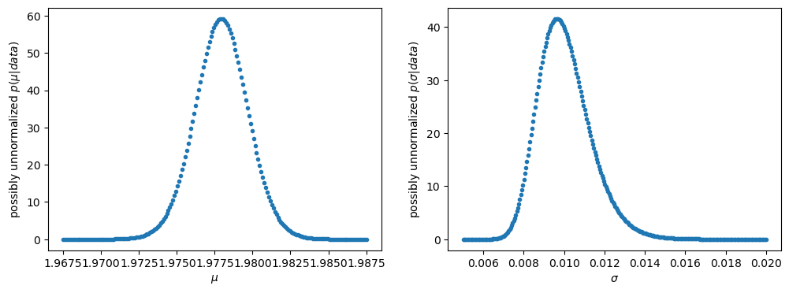

```python
# Checkpoint post1d_byI 0
plt.rcParams['figure.figsize'] = (12.0, 4.0)
fig, ax = plt.subplots(1,2);
ax[0].plot(grid_mu, marg_mu, '.');
ax[0].set_xlabel(param_labels[0]);
ax[0].set_ylabel('possibly unnormalized $p($'+param_labels[0]+'$|data)$');
ax[1].plot(grid_sigma, marg_sigma, '.');
ax[1].set_xlabel(param_labels[1]);
ax[1].set_ylabel('possibly unnormalized $p($'+param_labels[1]+'$|data)$');
# End checkpoint
```

```python
# this will test the marginalized posterior grids
# Tests margepost (1 point)
```

The cell below computes credible intervals using the highest-posterior-density definition you've seen in the notes. In this context, "fine enough gridding" of the posterior basically means that the PDF shapes are represented well enough these functions are able to identify the CIs correctly. In terms of the figures below, this means that each vertical blue line should intersect the PDF (black curve) in the same place that one of the horizontal/dashed green lines intersects it, rather than the blue line being obviously offset horizontally. If needed, return to the start of this section and iterate on the grid spacing.

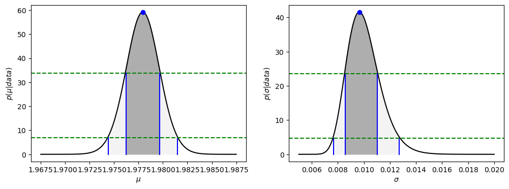

```python
# Checkpoint credint_byI 0
plt.rcParams['figure.figsize'] = (12.0, 4.0)
fig, ax = plt.subplots(1,len(param_labels))
CIs = []
CIs.append( cr.whist_ci({'x':grid_mu, 'density':marg_mu}, plot=ax[0]) )
CIs.append( cr.whist_ci({'x':grid_sigma, 'density':marg_sigma}, plot=ax[1]) )
for i,name in enumerate(param_labels):
    ax[i].set_xlabel(name);
    ax[i].set_ylabel('$p($'+name+'$|data)$');
# End checkpoint
```

Below, we'll print out the CI information, plot the 2D credible region and record the overall posterior mode, for later.

```python
CIs[0] # mu
```

```
{'mode': np.float64(1.9779522613065328),
 'level': array([0.68268949, 0.95449974]),
 'prob': array([0.68972894, 0.95548913]),
 'density': array([33.8156766 ,  6.88245611]),
 'min': array([1.97624372, 1.97443467]),
 'max': array([1.9796608 , 1.98146985]),
 'low': array([-0.00170854, -0.00351759]),
 'high': array([0.00170854, 0.00351759]),
 'center': array([1.97795226, 1.97795226]),
 'width': array([0.00170854, 0.00351759])}
```

```python
CIs[1] # sigma
```

```
{'mode': np.float64(0.009665551839464883),
 'level': array([0.68268949, 0.95449974]),
 'prob': array([0.69044352, 0.95586704]),
 'density': array([23.57891857,  4.74122947]),
 'min': array([0.00856187, 0.00765886]),
 'max': array([0.01102007, 0.01272575]),
 'low': array([-0.00110368, -0.00200669]),
 'high': array([0.00135452, 0.0030602 ]),
 'center': array([0.00979097, 0.01019231]),
 'width': array([0.0012291 , 0.00253344])}
```

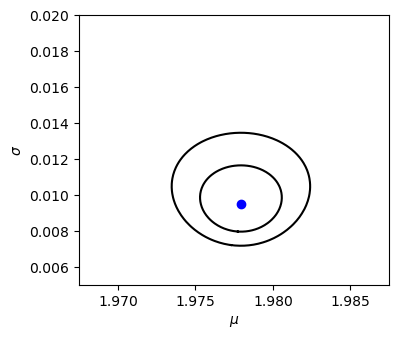

```python
plt.rcParams['figure.figsize'] = (4.0, 3.5)
CR = cr.whist2d_ci({'x':grid_mu, 'y':grid_sigma, 'z':np.exp(grid2_lnpost)}, plot=plt);
plt.xlabel(param_labels[0]);
plt.ylabel(param_labels[1]);
plt.xlim(grid_mu[0], grid_mu[-1]);
plt.ylim(grid_sigma[0], grid_sigma[-1]);
```

```python
CR['mode']
```

```
array([1.97795226, 0.00951505])
```

### Goodness of fit

It is *always* a good idea to check whether your fitted model actually describes the data well. We'll look at more sopisticated ways of doing so later in the course, and for now just do some visual comparisons of the posterior mode predictions to the data. In the first place, we could compare a histogram of the data, which is one way of estimating its empirical distribution, with the Gaussian that is the posterior mode model.

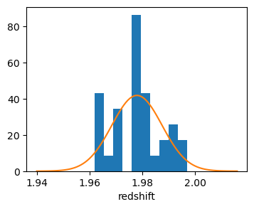

```python
plt.rcParams['figure.figsize'] = (4.0, 3.0)
plt.hist(z_gal, density=True);
plt.xlabel('redshift');
zs = CR['mode'][0] + np.linspace(-4.0, 4.0, 100) * CR['mode'][1]
plt.plot(zs, st.norm.pdf(zs, CR['mode'][0], CR['mode'][1]));
```

This should look plausible, but with so few galaxies in total, it's hard to say confidently that the empirical distribution resembles the model. The appearance of such comparisons is also extremely sensitive to the histogram binning. A somewhat more objective visualization is the quantile-quantile plot:

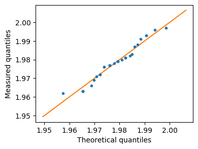

```python
plt.rcParams['figure.figsize'] = (4.0, 3.0)
plt.plot(st.norm.ppf(0.01*st.percentileofscore(z_gal, z_gal, kind='mean'), CR['mode'][0], CR['mode'][1]), z_gal, '.');
zs = CR['mode'][0] + np.linspace(-3.0, 3.0, 100) * CR['mode'][1]
plt.plot(zs, zs, zorder=0);
plt.xlabel('Theoretical quantiles');
plt.ylabel('Measured quantiles');
```

This plot shows the "measured quantiles", also known as the data themselves, with the corresponding "theoretical quantiles". The latter are the model's quantile function evaluated at the empirical CDF value corresponding to each data point. To be less abstract, the median galaxy redshift, $z_\mathrm{med}$, is plotted with a "measured quantile" of $z_\mathrm{med}$ and a "theoretical quantile" of $F^{-1}(0.5; \mu^\star, \sigma^\star)$, where $F^{-1}(\cdot; \mu^\star, \sigma^\star)$ is the Gaussian quantile function for the posterior mode, $(\mu^\star, \sigma^\star)$.

Regardless of the confusing definition, the bottom line is this: if the model is a good description of the data, then the points should lie close to the 1:1 line, rather than systematically diverging from it. For the data used in the solutions, this look pretty good.

Because our model was specifically that the data are drawn from a Gaussian, there are also classic quantitative tests that can be called on, such as the Shapiro Test and Anderson-Darling Test. These are an exercise for the reader, if so inclined.

# Solution with maximum likelihood

Just like Bayes on a grid, maximum likelihood on a grid will suffer from the limited resolution with which we are mapping out the parameter space. Also similarly, the grid approach is not the only one possible. In the case of maximum likelihood, the alternative would involve doing a large number of numerical minimizations to map out the various profile likelihoods.

Our first move is to evaluate the likelihood (alone) on a fine grid, just like we did with the posterior. It's likely (ahem) that the same grid will do well, but if not the cell below offers the opportunity to change the grid definition and iterate.

```python
# grid_mu = np.linspace(...)
# grid_sigma = np.linspace(...)
# grid2_mu, grid2_sigma = np.meshgrid(grid_mu, grid_sigma)

# YOUR CODE HERE
raise NotImplementedError()
```

Evaluate the likelihood, and do the basic check that the grid extent is sufficient.

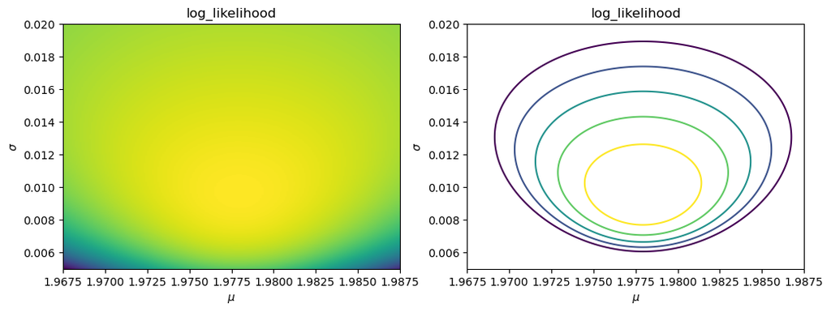

```python
# Checkpoint like2d_byI 0
grid2_lnlike = log_likelihood(z_gal, grid2_mu, grid2_sigma)

plt.rcParams['figure.figsize'] = (12.0, 4.0)
fig, ax = plt.subplots(1,2);
ax[0].imshow(grid2_lnlike, origin='lower', extent=[grid_mu[0], grid_mu[-1], grid_sigma[0], grid_sigma[-1]], aspect='auto');
ax[0].set_title("log_likelihood");
ax[0].set_xlabel(param_labels[0]);
ax[0].set_ylabel(param_labels[1]);
ax[1].contour(grid2_mu, grid2_sigma, grid2_lnlike, levels=grid2_lnlike.max()-np.arange(10.0, 0.0, -2.0));
ax[1].set_title("log_likelihood");
ax[1].set_xlabel(param_labels[0]);
ax[1].set_ylabel(param_labels[1]);
# End checkpoint
```

Next, we'll need to find the 1D confidence intervals for each parameter using the corresponding 1D profile likelihoods (see the Frequentism notes). Recall that we will be looking to satisfy the relation $\Delta S=S-S_\mathrm{min}$, where $S=-2\log(\mathrm{profile~likelihood})$, so let's skip directly to storing $\Delta S$ along the $\mu$ and $\sigma$ axes.

```python
# dS_mu = ...
# dS_sigma = ...

# YOUR CODE HERE
raise NotImplementedError()
```

Take a look:

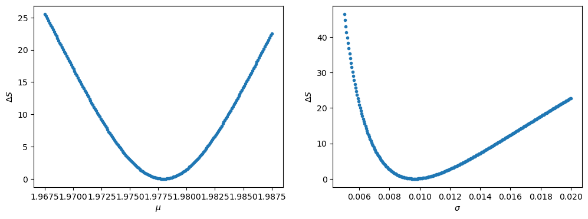

```python
# Checkpoint DeltaS_byI 0
plt.rcParams['figure.figsize'] = (12.0, 4.0)
fig, ax = plt.subplots(1,2);
ax[0].plot(grid_mu, dS_mu, '.');
ax[0].set_xlabel(param_labels[0]);
ax[0].set_ylabel(r'$\Delta S$')
ax[1].plot(grid_sigma, dS_sigma, '.');
ax[1].set_xlabel(param_labels[1]);
ax[1].set_ylabel(r'$\Delta S$');
# End checkpoint
```

Let's take a step back now and find the $(\mu,\sigma)$ corresponding to the maximum likelihood estimate. This can be done directly from `grid2_lnlike`, though one needs to be careful about index ordering. If your `dS_mu` and `dS_sigma` are correct, it's arguably more straightforward to find the maximum likelihood grid point from them. (We won't test this, so double check versus the 2 most recent sets of plots.)

```python
# ML_point = [..., ...]

# YOUR CODE HERE
raise NotImplementedError()
```

Let's see how it compares to the posterior mode.

```python
print('ML estimate:', ML_point)
print('Posterior mode:', CR['mode'])
print('Difference:', np.array(ML_point) - CR['mode'])
```

```
ML estimate: [1.97795226 0.00966555]
Posterior mode: [1.97795226 0.00951505]
Difference: [0.        0.0001505]
```

Returning to the frequentist confidence intervals, complete this function to find them from the profile likelihoods, recalling that these are the intervals where $\Delta S \leq$ a particular threshold value. No need for fancy interpolation or root finding, just return the on-grid endpoints of the intervals where the inequality is satisfied.

```python
# def find_condfidence_intervals(x, dS, thresholds):
    # x: grid where dS is evaluated (1D array, either grid_mu or grid_sigma)
    # dS: DeltaS at each x
    # thresholds: list of DeltaS thresholds
    # returns a dictionary {'min':xmin, 'max':xmax}, where xmin and xmax are lists (or arrays) with the same length as thresholds,
    #   containing the minimum/maximum of each interval

# YOUR CODE HERE
raise NotImplementedError()
```

The credible interval finder we used above produced intervals corresponding to 68.3% and 95.4% probability, so set `thresholds` below to compute confidence intervals at the equivalent levels.

```python
# thresholds = [..., ...]

# YOUR CODE HERE
raise NotImplementedError()
```

Let's run the function

```python
MLCIs = [find_condfidence_intervals(grid_mu, dS_mu, thresholds),
         find_condfidence_intervals(grid_sigma, dS_sigma, thresholds)]
```

and see what it produced

```python
MLCIs[0] # mu
```

```
{'min': array([1.97634422, 1.97453518]),
 'max': array([1.9795603 , 1.98136935])}
```

```python
MLCIs[1] # sigma
```

```
{'min': array([0.00861204, 0.00770903]),
 'max': array([0.0109699 , 0.01257525])}
```

This cell will compare the "best fits" and intervals, with a small horizontal offset for visibility. Unless we chose a very informative prior, chances are these are very similar between the two methods in this case.

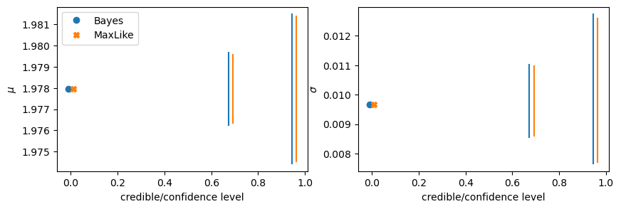

```python
# Checkpoint summary1d_byI 0
plt.rcParams['figure.figsize'] = (10.0, 3.0)
fig, ax = plt.subplots(1,2);
offset = 0.01
for i in range(2):
    ax[i].plot(0.0-offset, CIs[i]['mode'], 'o', color='C0', label='Bayes');
    ax[i].plot([0.683-offset]*2, [CIs[i]['min'][0], CIs[i]['max'][0]], '-', color='C0');
    ax[i].plot([0.954-offset]*2, [CIs[i]['min'][1], CIs[i]['max'][1]], '-', color='C0');
    ax[i].plot(0.0+offset, ML_point[i], 'X', color='C1', label='MaxLike');
    ax[i].plot([0.683+offset]*2, [MLCIs[i]['min'][0], MLCIs[i]['max'][0]], '-', color='C1');
    ax[i].plot([0.954+offset]*2, [MLCIs[i]['min'][1], MLCIs[i]['max'][1]], '-', color='C1');
    ax[i].set_xlabel('credible/confidence level');
    ax[i].set_ylabel(param_labels[i])
ax[0].legend();
# End checkpoint
```

```python
# this will test your thresholds and 1D confidence intervals
# Tests conf1d (1 point)
```

Finally, we'll have a look at the 2D confidence region, which is defined in terms of $\Delta S = S - S_\mathrm{min}$ in 2 dimensions. For the 2D case, fill in the $\Delta S$ thresholds corresponding to 68.3% and 95.4% confidence.

```python
# thresholds2 = [..., ...]

# YOUR CODE HERE
raise NotImplementedError()
```

With that, we can just use the Matplotlib `contour` function to compare these confidence regions with the credible regions from the Bayesian analysis. As with the 1D intervals, they are unlikely to differ much in this case.

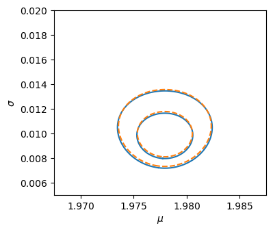

```python
# Checkpoint summary2d_byI 0
plt.rcParams['figure.figsize'] = (4.0, 3.5)
cr.ci2D_plot(CR, plt, Line2D_kwargs={'color':'C0'});
plt.contour(grid2_mu, grid2_sigma, -2.0*(grid2_lnlike-grid2_lnlike.max()), levels=thresholds2, colors='C1', linestyles='dashed');
plt.xlabel(param_labels[0]);
plt.ylabel(param_labels[1]);
# End checkpoint
```

```python
# this will test your thresholds for 2D confidence regions
# Tests conf2d (1 point)
```

# Parting thoughts

Unless we chose a particularly contrived prior distribution, you have now worked through the first inference problem in this course that can't be entirely done on paper! Hopefully this has been good practice, and we think it's nice to see how directly inferences follow from the prior and likelihood at least once, without more complex methods getting in the way. While we intentionally chose not to punish you with a slow-to-evaluate or high dimensional problem, it's hopefully also clear why we won't be working things out on a grid again, instead turning to computational methods that allow us to characterize posterior distributions without exhaustively evaluating them throughout their parameter spaces.

```python
# moar housekeeping
# Tests housekeeping2
```